# CIS 544 - Homework Assignment 2

### Problem 3

In this problem, you will develop a model to *predict whether a given car gets high or low gas mileage* based on the `Auto` data set.

Here we load the `MASS` package.

```r
library(MASS)
library(ISLR)
# Get a summary of the `Auto` data set
summary(Auto)
```

[output not shown]

```r
attach(Auto)
```

- Create a binary variable, `mpg01`, that contains a 1 if `mpg` contains a value above its median, and a 0 if `mpg` contains a value below its median. You can compute the median using the `median()` function. (One possible way to do this, is using the function `ifelse()`)

```r
Auto$mpg01<-ifelse(Auto$mpg>median(mpg),1,0)
mpg01fun<-ifelse(Auto$mpg>median(mpg),1,0)
```

- Explore the data graphically in order to investigate the association between `mpg01` and the rest of the features. Which of the other features seem most likely to be useful in predicting `mpg01`? Scatterplots and boxplots may be useful tools to answer this question. Describe your findings.

From the boxplot it seems that acceleration, displacement, horsepower, weight, and year have somewhat of a relationship with mpg01. From the correlation plot you can see a strong negative relationship with cylinders, displacement, horsepower, weight.

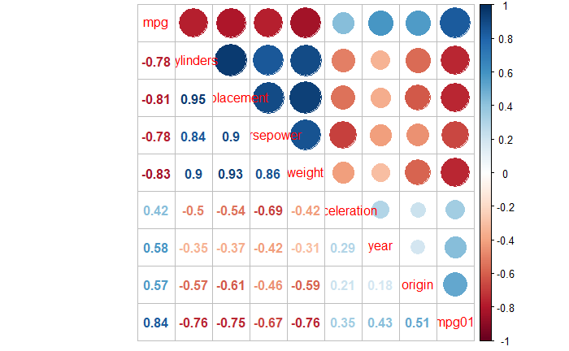

```r
library(corrplot)
#Removing column Name from Auto data frame
Nocat<-Auto[,-9]
#Correlation of each variable
a.cor<-cor(Nocat)
#Correlation plot to visually see the relationship between the variables
corrplot.mixed(a.cor)
```

```
Ignoring unknown aesthetics: xlab
```

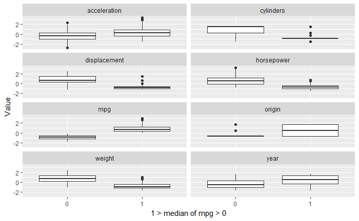

```r
#Scaling the Nocat data which contains every variable except mpg01
as<-scale(Nocat[,-9])
#Creating a new data frame inorder to use in boxplot
Auto.scale<-data.frame(as)
#Re-inserting the mpg01 vector since I removed it. I did it to avoid it from being scaled.
Auto.scale$mpg01<-mpg01fun
#Gathering my data in only 3 columns. It puts each column from Auto ontop of each other.
library(tidyr)
auto.scale.melt<-gather(Auto.scale,key = "mpg01")
#Changing the Column names
colnames(auto.scale.melt)<-c("Mpg01","Column.Name","Value")
#Plotting the boxplot with a facet_wrap to seperate the different boxplots
ggplot(data = auto.scale.melt, aes(x = as.factor(Mpg01), y = Value)) +
  geom_boxplot(aes(xlab="1>m>0")) + xlab("1 > median of mpg > 0") +
  facet_wrap(~ Column.Name, ncol = 2)
```

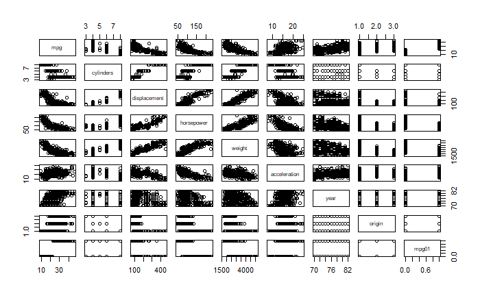

```r
plot(Nocat)
```

- Split the data into a training set and a test set.

```r
set.seed(305)
rows <- sample(x=nrow(Auto), size=0.75*nrow(Auto))
trainset <- Auto[rows,]
testset <- Auto[-rows,]
```

- Perform **LDA** (linear discriminant analysis) *on the training data* in order to predict `mpg01` using the variables that seemed most associated with `mpg01`. (Use at least 2 variables!)

```r
#LDA model on training data
lda.fit <- lda(mpg01~displacement+horsepower+weight+acceleration+year+cylinders+origin, data = trainset)
#Predicting the fit with the test data
lda.predict<- predict(lda.fit,testset)
#Confusion matrix
table(testset$mpg01, lda.predict$class)
```

```
     0  1
  0 44  6
  1  3 45
```

- What is the test error of the model?

```r
#Predicting the fir with the test data but only showing the column 0
lda.predictpost<- predict(lda.fit,testset)$posterior[,2]
misClassError(testset$mpg01,lda.predictpost)
```

```
[1] 0.0918
```

### Problem 4

The `MASS` library contains the `Boston` data set, which records `medv` (median house value) for 506 neighborhoods around Boston. We will seek to predict `medv` using 13 predictors such as `rm` (average number of rooms per house), `age` (average age of houses), and `lstat` (percent of households with low socioeconomic status).

*Problem*:

- Using the `Boston` data set, fit a **logistic regression** classification model in order to *predict whether a given suburb has a crime rate above or below the median* (crime rate is stored in variable `crim`). Describe your findings.

Use the following partition of the data

```r
library(MASS)
attach(Boston)
# Find values for which crime is above or below than the median
# Crime below the median (class 0)
crime01 <- rep(0, length(crim))
# Crime above the median (class 1)
crime01[crim > median(crim)] <- 1
# data frame with Boston data and "labels" for crime above/below median
Boston <- data.frame(Boston, crime01)
# Create train and test data
# Train data (indices)
train <- 1:(dim(Boston)[1]/2)
# Test data  (indices)
test  <- (dim(Boston)[1]/2+1):dim(Boston)[1]
Boston.train <- Boston[train,]
Boston.test <- Boston[test,]
crime01.test <- crime01[test]
```

- Use the `glm()` function to fit a logistic regression model. Test your classifier with the test data created above, create the *confussion matrix*, and describe your findings.

```r
Boston.glm.fit <-glm(crim01.train~zn + indus + chas + nox + rm + age + dis + rad + tax + ptratio + black + lstat + medv,family = binomial,data=Boston.train)
```

```
glm.fit: fitted probabilities numerically 0 or 1 occurred
```

```r
Boston.predict<-predict(Boston.glm.fit,newdata=Boston.test,type="response")
confusionMatrix(crime01.test,Boston.predict)
```

|  | 0 | 1 |
| --- | --- | --- |
| 0 | 68 | 24 |
| 1 | 22 | 139 |

```r
misClassError(crime01.test, Boston.predict)
```

```
[1] 0.1818
```

```r
#The FP and FN are not that low, but at the same time it is still not bad.Based on the misclassError roughly 18% of the data was wrong.
```